# Homework Task

2023-12-02

## QUESTION 01: Data Visualisation for Science Communication

### a) Provide your figure here:

```
##
##  /var/folders/87/fhjjd6p915790ktfr1c24tj40000gn/T//RtmpEmZJWy/downloaded_packages
```

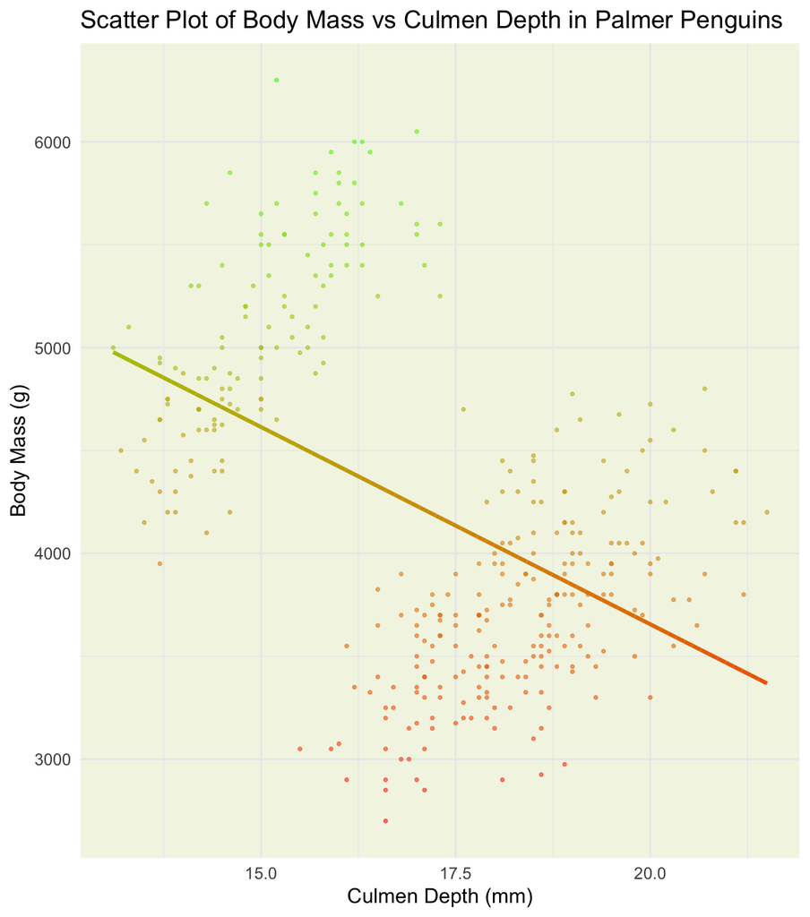

### b) Write about how your design choices mislead the reader about the underlying data (200-300 words).

‘Simpson’s Paradox’ refers to the phenomenon by which the association between variables in subgroups of a population are not accurately reflected in the population collectively due to the confounding effect of this underlying heterogeneity (Rücker and Schumacher, 2008). This causes negative relationships between variables to appear positive and vise versa. In my plot, I have presented the data for the association between body mass and culmen depth across all species, using a single line of best fit through this data to present a negative relationship. However, separating by species, as I have done below, illustrates this is not the relationship between properly the stratified data.

Several elements of the visual design also make this poorly representative of the data. Our categorical perception of colour can have a biasing effect on how data is interpreted (Franconeri et al. 2021). I have used this phenomenon to distort the effect of my plot in two ways: firstly, the gradient of colour of the points along the y-axis enhances the downward trajectory of the data, emphasising the negative linear gradient that I have misleadingly conveyed. Secondly, this smooth gradient of colour presents the data points as one cohesive dataset, drawing attention away from the clumping of data by species that might reveal how more stratification could highlight a different relationship between the variables.

Another visual effect that obfuscates the uneven distribution of the data is my choice to use very small points with low opacity. This makes it difficult to make individual points of data, and even harder to interpret them collectively. This difficult is additionally enhanced for colour blind or otherwise colour-vision impaired observed, who make up approximately 4% of the global population (Olsen and Brewer, 1997).

The final visual element that slightly distorts my graph is the manipulation of the axes. Stretching the y-axis so that it is slightly longer than the x-axis increases the slope of the linear line of best fit, emphasising the negative relationship further (Franconeri et al. 2021).

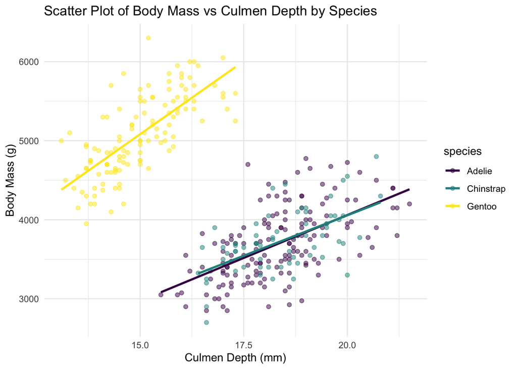

References:

*Franconeri, S. L. et al. (2021)* The Science of Visual Data Communication: What Works. [Online]

*Olson, J. M. & Brewer, C. A. (1997)* An Evaluation of Color Selections to Accommodate Map Users with Color-Vision Impairments. Annals of the Association of American Geographers. [Online] 87 (1), 103–134.

*Rücker, G. & Schumacher, M. (2008)* Simpson’s paradox visualized: the example of the rosiglitazone meta-analysis. BMC medical research methodology. [Online] 8 (1), 34–34.

## QUESTION 2: Data Pipeline

### a) Introduction

Upon initial examination in Question 1, I noted a positive correlation between culmen depth and body mass across various penguin species. This observation prompts a closer investigation into whether this correlation holds true specifically for Adelie penguins.

The assumption of a linear relationship between culmen depth and body mass suggests a proportional growth of this feature with body mass. However, such a correlation might not be as straightforward if the feature serves a purpose beyond mere size indication. In ecological contexts, certain species may exhibit unique organ development patterns that are not strictly proportional to body size due to community roles or other factors.

In this analysis, I aim to test the hypothesis that culmen depth is linearly proportional to body mass in Adelie penguins. A positive linear trend may suggest a direct relationship between the two variables, while deviations from linearity could imply additional ecological complexities.

### b) Cleaning the data

I cleaned the raw data to remove columns that were not relevant to my research (such as clutch completion, flipper length etc.), eliminated rows with N/A values in the variables of interest, cleaned the column names, and shortened the species names. Additionally, I subsetted the data to only include the Adelie penguin species as this was my focal species for this analysis.

I then created an exploratory scatter plot to present the association between culmen depth and body mass in the Adelie penguins. This appears to show a positive relationship between these variables.

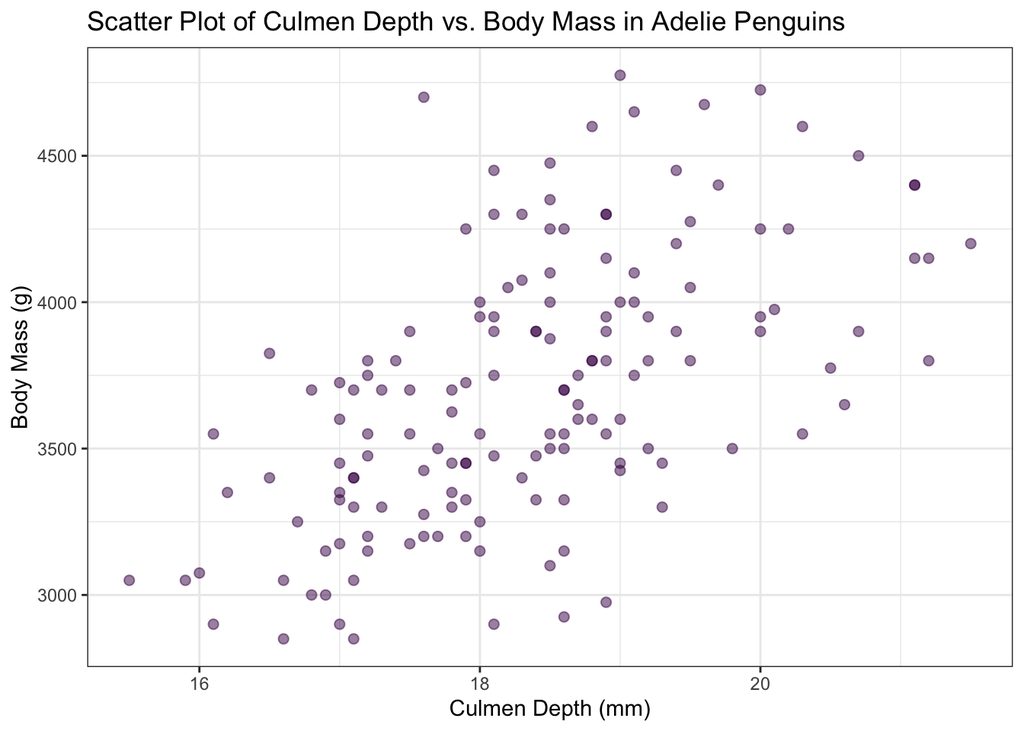

```r
source("Functions/Plotting.R")

# Plotting Body Mass and Culmen Depth with penguins in Adelie penguins alone
adelie_culmen_depth_body_mass_plot <- create_adelie_culmen_depth_body_mass_scatter_plot(penguins_clean_question_2)
print(adelie_culmen_depth_body_mass_plot)
```

### c) Hypothesis

Alternative Hypothesis: there is a statistically significant linear relationship between the independent variable (culmen depth) and the dependent variable (body mass).

Null Hypothesis: there is not a statistically significant linear relationship between the independent variable (culmen depth) and the dependent variable (body mass).

### d) Statistical Methods

I have used a simple linear regression to test for the association between these variables. This allows me to quantify the strength and direction of the relationship and test for the statistical significance of this association.

```r
source("Functions/Statistical_Testing.R")

# Creating a linear model to test culmen depth against body mass in Adelie penguins
linear_model_culmen_depth_body_mass <-
create_linear_model_culmen_depth_body_mass(penguins_clean_question_2)

# Summary of this model output
summary(linear_model_culmen_depth_body_mass)
```

```
##
## Call:
## lm(formula = body_mass_g ~ culmen_depth_mm, data = data)
##
## Residuals:
##     Min      1Q  Median      3Q     Max
## -845.89 -259.67  -55.74  267.98 1161.41
##
## Coefficients:
##                 Estimate Std. Error t value Pr(>|t|)
## (Intercept)      -283.28     464.03  -0.610    0.542
## culmen_depth_mm   217.15      25.24   8.604 9.94e-15 ***
## ---
## Signif. codes:  0 '***' 0.001 '**' 0.01 '*' 0.05 '.' 0.1 ' ' 1
##
## Residual standard error: 376.1 on 149 degrees of freedom
## Multiple R-squared:  0.3319, Adjusted R-squared:  0.3275
## F-statistic: 74.03 on 1 and 149 DF,  p-value: 9.942e-15
```

I then used a Shapiro-Wilk test to establish whether my variables were normally distributed, fulfilling the requirements of the regression, or whether transformation of the data was required. I also plotted my residuals using a Q-Q plot to visually assess their normality.

```r
# Conducting a Shapiro-Wilk test on the linear model
shapiro_test <- shapiro.test(residuals(linear_model_culmen_depth_body_mass))
shapiro_test
```

```
##
##  Shapiro-Wilk normality test
##
## data:  residuals(linear_model_culmen_depth_body_mass)
## W = 0.98831, p-value = 0.2387
```

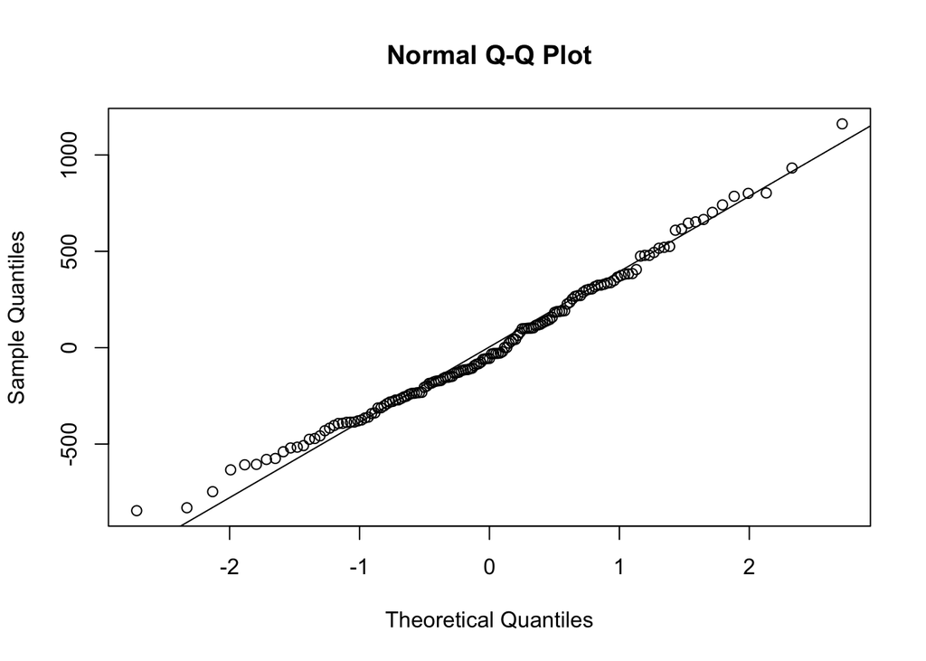

```r
# Generating a Q-Q plot of residuals
qqnorm(residuals(linear_model_culmen_depth_body_mass))
qqline(residuals(linear_model_culmen_depth_body_mass))
```

### e) Results & Discussion

Based on visual inspection of the Q-Q plot, the residuals in my linear regression seemed approximately normal. Furthermore, the p-value of the Shapiro-Wilk test is 0.2387, which is greater than 0.05, therefore there is no statistically significant evidence to suggest that the residuals are not normally distributed.

My linear regression analysis provides strong support for the hypothesis of a significant positive relationship between body mass and culmen depth in the Adelie species of penguin. The coefficient of 217.15 indicates that, on average, for every additional millimeter of culmen depth, the body mass of the penguins increases by 217.15 grams.

The extremely low p-value of 9.942e-15 provides good evidence to reject the null hypothesis, indicating that culmen depth is indeed a statistically significant predictor of body mass in this species using a linear model.

Furthermore, the Multiple R-squared value of 0.3319 suggests that approximately 33.19% of the variability in body mass can be explained by culmen depth. While not capturing the entire variance, this model represents a reasonable fit to the data, providing useful insights into the relationship between these two variables.

Overall, these findings suggest that culmen depth is grows in proportion with the overall body mass of Adelie penguins, suggesting that the growth of this feature does not have particular ecological significance. The plot below provides a visualisation of the positive linear relationship that I found between the variables in my data. It is also important to acknowledge, however, that there are limitations to this research that may limit the generality of my conclusions. I focused solely on the Adelie penguin species, and thus this relationship may not extend to other penguin species or bird populations. Furthermore, this model assumes a linear relationship between culmen depth and body mass, whilst other ecological factors may introduce non-linear complexities. More complex modelling strategies could be considered in the future in order to broaden our understanding of the relationship between these variables.

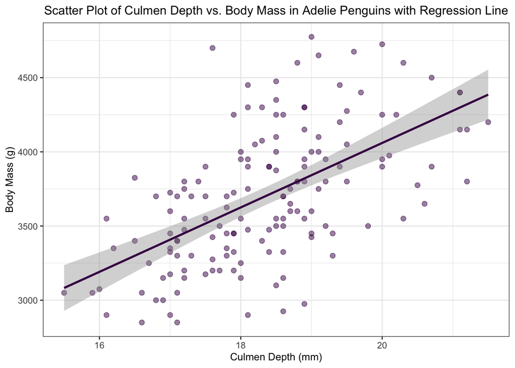

```r
source("Functions/Plotting.R")

# Plotting Body Mass and Culmen Depth with penguins in Adelie penguins with a line to represent the regression line
adelie_culmen_depth_body_mass_plot_regression <- create_adelie_culmen_depth_body_mass_scatter_plot_regression(penguins_clean_question_2)
print(adelie_culmen_depth_body_mass_plot_regression)
```

### f) Conclusion

In summary, this study investigated the relationship between culmen depth and body mass in Adelie penguins. Cleaning and pre-processing the data revealed a positive correlation, and a subsequent linear regression analysis provided robust evidence for a significant positive linear relationship. The coefficient of 217.15 suggested that, on average, a one millimeter increase in culmen depth corresponded to a 217.15 gram increase in body mass. Normality checks supported the reliability of the results. These findings contribute valuable insights into the proportional growth of culmen depth with body mass in Adelie penguins, shedding light on their anatomical development.

## QUESTION 3: Open Science

### a) GitHub

*GitHub link:* https://github.com/AnonymousBiology/Penguins-Reproducible-Data-Homework

### b) Share your repo with a partner, download, and try to run their data pipeline.

*Partner’s GitHub link:* https://github.com/anonymoose2/reproducible_penguins_assignment

### c) Reflect on your experience running their code. (300-500 words)

My partner’s code ran successfully, with the exception of the “save_png” and “save_svg” commands, which produced the output “null device 1”. I looked into why this error might be occurring and found that it might be an issue with the agg_png() function that was used to save the graph images. Using a base R or ggplot saving function might resolve this issue. However, this did not detract at all from my understanding of the data pipeline, as saving images is not necessary to addressing the question itself anyway. Everything else ran with no errors at all.

There was a clear explanation before every chunk of code in the rmarkdown, which made it really easy to understand what code was being used and why. Furthermore, the source code for functions were saved in a separate document, meaning that the code in the pipeline was concise, yet I could access the details if needed. I would perhaps suggest separating the functions document into multiple files to separate cleaning, plotting and saving, as this would make it easier to navigate through the directory. Perhaps also labeling the functions with more specific names, particularly if they are fulfilling very specific tasks, (such as plotting one type of graph or saving a particular document) would be beneficial to allow me to understand what they do when I was just looking at the functions assignment, as I had to cross reference with the main rmd to understand what some functions were used for. Despite these suggested improvements, it was easy to find any specific functions that I searched for there were not too many functions in the document anyway.

It would be very simple to alter a figure in my partner’s code given how they have laid it out. I could copy the function that they used to generate a plot, alter it to my liking, and then save that as a new function. This would preserve their work, whilst allowing more to explore my own questions around it. Having their data and figures already saved within the repository also means that I would not lose access to the original findings even if I accidentally modified the code they used to produce this.

### d) Reflect on your own code based on your experience with your partner’s code and their review of yours. (300-500 words)

My partner noted that my packages only worked once they had updated r from the 2022 (4.2.2) version to the 2023 (4.3.2) version. It would perhaps be useful to put a note in my markdown document to remind anyone using my code to make sure they have updated r to version 4.3.2 or higher for optimal performance. I could also review my choice of packages and potentially reconsider external packages that seem to be less operational with earlier versions of r if there is a base package alternative. This issue highlighted to me the importance of testing a coding pipeline on a variety of operating systems and environments, as many potential issues of reproducibility are not clear from the device that the code is written on. In a bigger project, it could be beneficial to compile a document to inform users about all the potential issues that could arise and suggest resolutions for specific error messages based on more thorough testing. I imagine it is also important to routinely chekc in and update the code once it is published as future updates alter the functionality of packages.

My partner also mentioned that my function names are quite long, which makes the code in my r markdown document slightly longer and harder to follow. I found it difficult to make my function names specific to what they are doing, whilst also remaining concise, but I agree that I could make them less detailed for the sake of brevity.

Working through my partner’s code really highlighted the importance of clearly labeling coding files and making it easy to navigate through a data pipeline, particularly when code is stored across many files, and the subject matter is unfamiliar. Having a modular design, in which different files encode each of the respective tasks within the code is a good way the achieve this clarity, and enables the central markdown document to remain uncluttered. Furthermore, viewing another pipeline example helped me to appreciate the importance of creating a user friendly interface via the design of the html or pdf document, which is visually appealing and breaks down the code in clear steps in order to make the methodology really comprehensible.